# R Notebook - Analise e Estimacao do CAPM para Diferentes Ativos

Igor Neves Nunes

## R Notebooks

Este é um R Notebook. Quando você executa o código R no notebook, os resultados aparecem abaixo do código.

O código R precisa estar em “pedaços” (*chunks*) em um Notebook R. Logo abaixo, está um exemplo de um pedaço de código R. O código produz uma parábola.

Tente executar este cógdigo, colocando o cursor dentro do **chunk** e clicando no botão *Run* (que pode ser acessado pela seta verde no canto superior direito do código ou pelo menu *Run* do RStudio), ou colocando o cursor dentro do código e pressionando *Ctrl+Shift+Enter* (Windows/Linux):

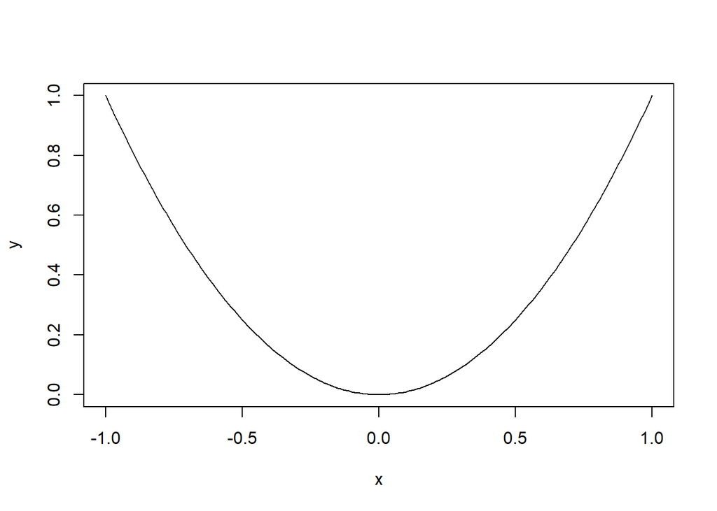

```r
x <- seq(-1, 1, by = 0.01)
y <- x^2
plot(x, y, type = "l")
```

Para ocultar a saída, clique nas setas para expandir/recolher a saída. Para limpar os resultados (ou um erro), clique no botão “x”.

Você também pode pressionar *Ctrl+Enter* (Win/Linux) para executar uma linha de código por vez (em vez de todo o bloco).

Adicione um novo pedaço de código R clicando no botão *Insert new code chunk* na barra de ferramentas ou pressionando *Ctrl+Alt+I* (Windows/Linux).

# Descrição

Este notebook R realiza a análise e estimação do CAPM (*Capital Asset Pricing Model*) para uma série de preços de acões, incluindo Ford, General Electric, Microsoft, Oracle e o índice S&P 500. O script busca atualizar o código disponibilizado por Brooks (2019).

# Pacotes Utilizados

```r
library(here)      # Permite utilizar caminhos relativos no projeto
library(tidyverse) # Metapacote que inclui dplyr, ggplot2, etc.
library(readxl)    # Para importar planilhas Excel
library(nanoparquet) # Para leitura e escrita de arquivos Parquet
library(skimr)       # alternativa para summary()
```

# 1. Importação dos Dados

Define o caminho para o arquivo Excel contendo os dados:

```r
path_capm <- here::here("data/raw/capm.xls")
```

Importa os dados da planilha Excel:

```r
dados_capm <- readxl::read_xls(path_capm)
```

Verifica a estrutura dos dados importados:

```r
dplyr::glimpse(dados_capm)
```

```
## Rows: 194
## Columns: 7
## $ Date      <dttm> 2002-01-01, 2002-02-01, 2002-03-01, 2002-04-01, 2002-05-01,…
## $ SANDP     <dbl> 1130.20, 1106.73, 1147.39, 1076.92, 1067.14, 989.82, 911.62,…
## $ FORD      <dbl> 15.30, 14.88, 16.49, 16.00, 17.65, 16.00, 13.47, 11.77, 9.80…
## $ GE        <dbl> 37.15, 38.50, 37.40, 31.55, 31.14, 29.05, 32.20, 30.15, 24.6…
## $ MICROSOFT <dbl> 31.855, 29.170, 30.155, 26.130, 25.455, 27.350, 23.990, 24.5…
## $ ORACLE    <dbl> 17.26, 16.62, 12.80, 10.04, 7.92, 9.47, 10.01, 9.59, 7.86, 1…
## $ USTB3M    <dbl> 1.68, 1.76, 1.83, 1.75, 1.76, 1.73, 1.71, 1.65, 1.66, 1.61, …
```

Gera estatísticas descritivas básicas para os dados:

```r
summary(dados_capm)
```

```
##       Date                            SANDP             FORD
##  Min.   :2002-01-01 00:00:00.00   Min.   : 729.6   Min.   : 1.870
##  1st Qu.:2006-01-08 18:00:00.00   1st Qu.:1127.2   1st Qu.: 8.527
##  Median :2010-01-16 12:00:00.00   Median :1323.5   Median :11.740
##  Mean   :2010-01-15 09:46:23.50   Mean   :1468.9   Mean   :11.430
##  3rd Qu.:2014-01-24 06:00:00.00   3rd Qu.:1854.7   3rd Qu.:14.168
##  Max.   :2018-02-01 00:00:00.00   Max.   :2816.4   Max.   :17.650
##        GE          MICROSOFT         ORACLE          USTB3M
##  Min.   : 8.51   Min.   :16.15   Min.   : 7.86   Min.   :0.010
##  1st Qu.:20.72   1st Qu.:25.87   1st Qu.:13.95   1st Qu.:0.080
##  Median :26.95   Median :28.35   Median :22.71   Median :0.480
##  Mean   :26.59   Mean   :34.75   Mean   :25.97   Mean   :1.241
##  3rd Qu.:32.70   3rd Qu.:38.27   3rd Qu.:36.48   3rd Qu.:1.725
##  Max.   :41.40   Max.   :95.01   Max.   :51.59   Max.   :5.160
```

Apresenta uma visão geral mais detalhada dos dados:

```r
skimr::skim(dados_capm)
```

Data summary

| Name | dados_capm |
| --- | --- |
| Number of rows | 194 |
| Number of columns | 7 |
| _______________________ |  |
| Column type frequency: |  |
| numeric | 6 |
| POSIXct | 1 |
| ________________________ |  |
| Group variables | None |

**Variable type: numeric**

| skim_variable | n_missing | complete_rate | mean | sd | p0 | p25 | p50 | p75 | p100 | hist |
| --- | --- | --- | --- | --- | --- | --- | --- | --- | --- | --- |
| SANDP | 0 | 1 | 1468.90 | 472.53 | 729.57 | 1127.21 | 1323.53 | 1854.73 | 2816.45 | ▆▇▂▃▁ |
| FORD | 0 | 1 | 11.43 | 3.55 | 1.87 | 8.53 | 11.74 | 14.17 | 17.65 | ▁▅▇▇▆ |
| GE | 0 | 1 | 26.59 | 7.38 | 8.51 | 20.72 | 26.95 | 32.70 | 41.40 | ▂▆▆▇▃ |
| MICROSOFT | 0 | 1 | 34.75 | 15.04 | 16.15 | 25.87 | 28.35 | 38.27 | 95.01 | ▇▂▁▁▁ |
| ORACLE | 0 | 1 | 25.97 | 12.04 | 7.86 | 13.95 | 22.71 | 36.47 | 51.59 | ▇▆▅▆▂ |
| USTB3M | 0 | 1 | 1.24 | 1.57 | 0.01 | 0.08 | 0.48 | 1.72 | 5.16 | ▇▂▁▁▂ |

**Variable type: POSIXct**

| skim_variable | n_missing | complete_rate | min | max | median | n_unique |
| --- | --- | --- | --- | --- | --- | --- |
| Date | 0 | 1 | 2002-01-01 | 2018-02-01 | 2010-01-16 12:00:00 | 194 |

# 2. Preparação dos Dados

## 2.1 Cálculo dos Retornos Compostos Continuamente (Logaritmícos)

Calcula e adiciona colunas correspondentes aos retornos compostos continuamente (logarítmicos) à data frame:

```r
dados_capm_retornos <- dados_capm %>%
  mutate(
    ret_sp500 = c(NA, 100 * diff(log(SANDP))),
    ret_ford = c(NA, 100 * diff(log(FORD))),
    ret_ge = c(NA, 100 * diff(log(GE))),
    ret_microsoft = c(NA, 100 * diff(log(MICROSOFT))),
    ret_oracle = c(NA, 100 * diff(log(ORACLE)))
  )
```

Verifica a estrutura da nova base de dados com os retornos:

```r
dplyr::glimpse(dados_capm_retornos)
```

```
## Rows: 194
## Columns: 12
## $ Date          <dttm> 2002-01-01, 2002-02-01, 2002-03-01, 2002-04-01, 2002-05…
## $ SANDP         <dbl> 1130.20, 1106.73, 1147.39, 1076.92, 1067.14, 989.82, 911…
## $ FORD          <dbl> 15.30, 14.88, 16.49, 16.00, 17.65, 16.00, 13.47, 11.77, …
## $ GE            <dbl> 37.15, 38.50, 37.40, 31.55, 31.14, 29.05, 32.20, 30.15, …
## $ MICROSOFT     <dbl> 31.855, 29.170, 30.155, 26.130, 25.455, 27.350, 23.990, …
## $ ORACLE        <dbl> 17.26, 16.62, 12.80, 10.04, 7.92, 9.47, 10.01, 9.59, 7.8…
## $ USTB3M        <dbl> 1.68, 1.76, 1.83, 1.75, 1.76, 1.73, 1.71, 1.65, 1.66, 1.…
## $ ret_sp500     <dbl> NA, -2.0984861, 3.6080107, -6.3384655, -0.9122969, -7.52…
## $ ret_ford      <dbl> NA, -2.7834799, 10.2736107, -3.0165414, 9.8147061, -9.81…
## $ ret_ge        <dbl> NA, 3.56944163, -2.89874834, -17.00972006, -1.30804230, …
## $ ret_microsoft <dbl> NA, -8.8053572, 3.3209996, -14.3266739, -2.6171854, 7.18…
## $ ret_oracle    <dbl> NA, -3.7784836, -26.1161679, -24.2868057, -23.7185908, 1…
```

## 2.2. Cálculo dos Retornos Excedentes

Calcula os retornos excedentes para cada ativo, ajustando pela taxa de rendimentos dos títulos do tesouro dos EUA (USTB3M):

```r
dados_capm_retexc <- dados_capm_retornos %>%
  mutate(
    # ajusta a série anual de rendimentos para base mensal
    ustb3m = USTB3M / 12,
    # calcula os retornos excedentes
    retexc_sp500 = ret_sp500 - ustb3m,
    retexc_ford = ret_ford - ustb3m,
    retexc_ge = ret_ge - ustb3m,
    retexc_microsoft = ret_microsoft - ustb3m,
    retexc_oracle = ret_oracle - ustb3m
  )
```

Verifica a estrutura da data frame com os retornos excedentes:

```r
dplyr::glimpse(dados_capm_retexc)
```

```
## Rows: 194
## Columns: 18
## $ Date             <dttm> 2002-01-01, 2002-02-01, 2002-03-01, 2002-04-01, 2002…
## $ SANDP            <dbl> 1130.20, 1106.73, 1147.39, 1076.92, 1067.14, 989.82, …
## $ FORD             <dbl> 15.30, 14.88, 16.49, 16.00, 17.65, 16.00, 13.47, 11.7…
## $ GE               <dbl> 37.15, 38.50, 37.40, 31.55, 31.14, 29.05, 32.20, 30.1…
## $ MICROSOFT        <dbl> 31.855, 29.170, 30.155, 26.130, 25.455, 27.350, 23.99…
## $ ORACLE           <dbl> 17.26, 16.62, 12.80, 10.04, 7.92, 9.47, 10.01, 9.59, …
## $ USTB3M           <dbl> 1.68, 1.76, 1.83, 1.75, 1.76, 1.73, 1.71, 1.65, 1.66,…
## $ ret_sp500        <dbl> NA, -2.0984861, 3.6080107, -6.3384655, -0.9122969, -7…
## $ ret_ford         <dbl> NA, -2.7834799, 10.2736107, -3.0165414, 9.8147061, -9…
## $ ret_ge           <dbl> NA, 3.56944163, -2.89874834, -17.00972006, -1.3080423…
## $ ret_microsoft    <dbl> NA, -8.8053572, 3.3209996, -14.3266739, -2.6171854, 7…
## $ ret_oracle       <dbl> NA, -3.7784836, -26.1161679, -24.2868057, -23.7185908…
## $ ustb3m           <dbl> 0.14000000, 0.14666667, 0.15250000, 0.14583333, 0.146…
## $ retexc_sp500     <dbl> NA, -2.2451528, 3.4555107, -6.4842988, -1.0589636, -7…
## $ retexc_ford      <dbl> NA, -2.9301466, 10.1211107, -3.1623748, 9.6680394, -9…
## $ retexc_ge        <dbl> NA, 3.4227750, -3.0512483, -17.1555534, -1.4547090, -…
## $ retexc_microsoft <dbl> NA, -8.9520238, 3.1684996, -14.4725072, -2.7638521, 7…
## $ retexc_oracle    <dbl> NA, -3.9251503, -26.2686679, -24.4326390, -23.8652575…
```

## 2.3. Armazenamento dos Dados Limpos em Diferentes Formatos

define um caminho relativo para salvar os dados limpos no formato .rds:

```r
path_clean <- here::here("data/clean/dados_capm_clean.rds")
write_rds(dados_capm_retexc, path_clean)
```

define o caminho para salvar os dados limpos no formato .csv:

```r
path_csv <- here::here("data/clean/dados_capm_clean.csv")
write_csv(dados_capm_retexc, path_csv)
```

define o caminho para salvar os dados limpos no formato .parquet:

```r
path_parquet <- here::here("data/clean/dados_capm_clean.parquet")
write_parquet(dados_capm_retexc, path_parquet)
```

## 3. Análise exploratória dos dados

Importa os dados limpos no formato .rds para análise:

```r
path_clean <- here::here("data/clean/dados_capm_clean.rds")
dados_capm_retexc <- readr::read_rds(path_clean)
```

remove valores faltantes dos dados para a análise:

```r
dados_capm_retexc <- dados_capm_retexc %>% drop_na()
dplyr::glimpse(dados_capm_retexc)
```

```
## Rows: 193
## Columns: 18
## $ Date             <dttm> 2002-02-01, 2002-03-01, 2002-04-01, 2002-05-01, 2002…
## $ SANDP            <dbl> 1106.73, 1147.39, 1076.92, 1067.14, 989.82, 911.62, 9…
## $ FORD             <dbl> 14.88, 16.49, 16.00, 17.65, 16.00, 13.47, 11.77, 9.80…
## $ GE               <dbl> 38.50, 37.40, 31.55, 31.14, 29.05, 32.20, 30.15, 24.6…
## $ MICROSOFT        <dbl> 29.170, 30.155, 26.130, 25.455, 27.350, 23.990, 24.54…
## $ ORACLE           <dbl> 16.62, 12.80, 10.04, 7.92, 9.47, 10.01, 9.59, 7.86, 1…
## $ USTB3M           <dbl> 1.76, 1.83, 1.75, 1.76, 1.73, 1.71, 1.65, 1.66, 1.61,…
## $ ret_sp500        <dbl> -2.0984861, 3.6080107, -6.3384655, -0.9122969, -7.521…
## $ ret_ford         <dbl> -2.7834799, 10.2736107, -3.0165414, 9.8147061, -9.814…
## $ ret_ge           <dbl> 3.56944163, -2.89874834, -17.00972006, -1.30804230, -…
## $ ret_microsoft    <dbl> -8.8053572, 3.3209996, -14.3266739, -2.6171854, 7.180…
## $ ret_oracle       <dbl> -3.7784836, -26.1161679, -24.2868057, -23.7185908, 17…
## $ ustb3m           <dbl> 0.14666667, 0.15250000, 0.14583333, 0.14666667, 0.144…
## $ retexc_sp500     <dbl> -2.2451528, 3.4555107, -6.4842988, -1.0589636, -7.665…
## $ retexc_ford      <dbl> -2.9301466, 10.1211107, -3.1623748, 9.6680394, -9.958…
## $ retexc_ge        <dbl> 3.4227750, -3.0512483, -17.1555534, -1.4547090, -7.09…
## $ retexc_microsoft <dbl> -8.9520238, 3.1684996, -14.4725072, -2.7638521, 7.036…
## $ retexc_oracle    <dbl> -3.9251503, -26.2686679, -24.4326390, -23.8652575, 17…
```

### 3.1 Estatísticas Descritivas

Calcula estatísticas descritivas dos retornos excedentes da Ford:

```r
dados_capm_retexc %>%
  summarise(
    media = mean(retexc_ford),
    mediana = median(retexc_ford),
    desvio_padrao = sd(retexc_ford),
    minimo = min(retexc_ford),
    maximo = max(retexc_ford),
    curtose = fBasics::kurtosis(retexc_ford),
    assimetria = fBasics::skewness(retexc_ford)
  ) %>%
  pivot_longer(cols = everything(),
               names_to = "Estatísticas (Ford)",
               values_to = "valor")
```

| Estatísticas (Ford) | valor |
| --- | --- |
| media | -0.2929348 |
| mediana | -1.0619814 |
| desvio_padrao | 13.4515614 |
| minimo | -86.5332082 |
| maximo | 82.1303388 |
| curtose | 14.6172275 |
| assimetria | 0.0541541 |

Calcula estatísticas descritivas dos retornos excedentes do S&P 500:

```r
dados_capm_retexc %>%
  summarise(
    media = mean(retexc_sp500),
    mediana = median(retexc_sp500),
    desvio_padrao = sd(retexc_sp500),
    minimo = min(retexc_sp500),
    maximo = max(retexc_sp500),
    curtose = fBasics::kurtosis(retexc_sp500),
    assimetria = fBasics::skewness(retexc_sp500)
  ) %>%
  pivot_longer(cols = everything(),
               names_to = "Estatísticas (S&P 500)",
               values_to = "valor")
```

| Estatísticas (S&P 500) | valor |
| --- | --- |
| media | 0.3508653 |
| mediana | 0.9490001 |
| desvio_padrao | 4.1346600 |
| minimo | -18.4414724 |
| maximo | 10.0638743 |
| curtose | 2.2772350 |
| assimetria | -0.9182357 |

Gera um gráfico de dispersão dos retornos excedentes da Ford vs. S&P 500:

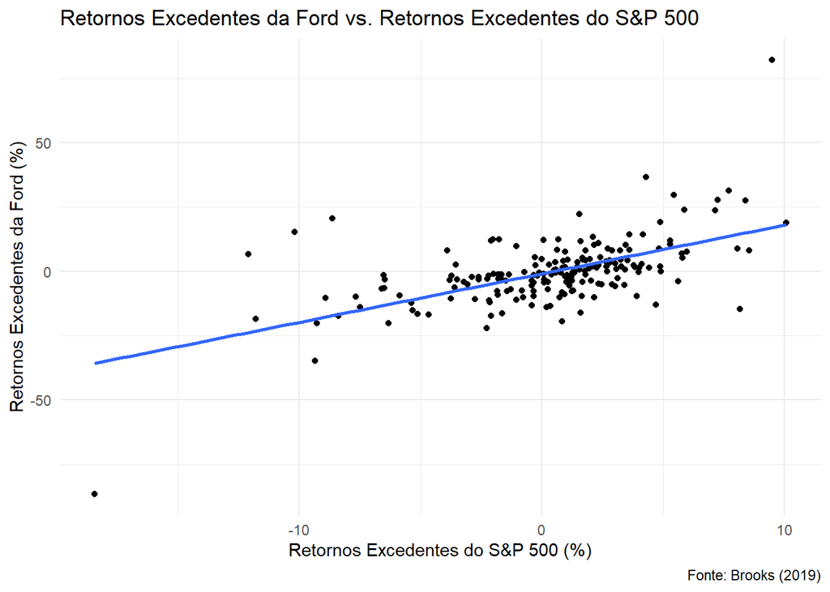

```r
ford_dispersao <-
  ggplot(
    dados_capm_retexc,
    aes(x = retexc_sp500, y = retexc_ford)
  ) +
  geom_point() +
  geom_smooth(method = "lm", se = FALSE) +
  labs(
    title = "Retornos Excedentes da Ford vs. Retornos Excedentes do S&P 500",
    caption = "Fonte: Brooks (2019)",
    x = "Retornos Excedentes do S&P 500 (%)",
    y = "Retornos Excedentes da Ford (%)"
  ) +
  theme_minimal()

## exibe o gráfico gerado
ford_dispersao
```

## 4. Estimação do modelo CAPM - Ford

Estima o modelo CAPM para os retornos excedentes da Ford:

```r
capm_ford <- lm(retexc_ford ~ retexc_sp500, data = dados_capm_retexc)
```

Exibe o resumo dos resultados da estimação do CAPM para a Ford:

```r
summary(capm_ford)
```

```
##
## Call:
## lm(formula = retexc_ford ~ retexc_sp500, data = dados_capm_retexc)
##
## Residuals:
##     Min      1Q  Median      3Q     Max
## -50.727  -5.027  -1.080   3.482  65.145
##
## Coefficients:
##              Estimate Std. Error t value Pr(>|t|)
## (Intercept)   -0.9560     0.7931  -1.205     0.23
## retexc_sp500   1.8898     0.1916   9.862   <2e-16 ***
## ---
## Signif. codes:  0 '***' 0.001 '**' 0.01 '*' 0.05 '.' 0.1 ' ' 1
##
## Residual standard error: 10.98 on 191 degrees of freedom
## Multiple R-squared:  0.3374, Adjusted R-squared:  0.3339
## F-statistic: 97.26 on 1 and 191 DF,  p-value: < 2.2e-16
```

Podemos ver os resultados contidos no objeto `capm_ford` usando a funcão `names` para listar os elementos disponíveis:

```r
names(capm_ford)
```

```
##  [1] "coefficients"  "residuals"     "effects"       "rank"
##  [5] "fitted.values" "assign"        "qr"            "df.residual"
##  [9] "xlevels"       "call"          "terms"         "model"
```

`coefficients`: contém os coeficientes estimados do modelo ($\hat{\beta}_0$ e $\hat{\beta}_1$):

```r
capm_ford$coefficients
```

```
##  (Intercept) retexc_sp500
##   -0.9559845    1.8897554
```

```r
head(capm_ford$residuals)
```

```
##         1         2         3         4         5         6
##  2.268628  4.547025 10.047349 12.625206  5.483224 -0.576933
```

`fitted.values`: contém os valores previstos ou ajustados pelo modelo ($\hat{y_i}$):

```r
head(capm_ford$fitted.values)
```

```
##          1          2          3          4          5          6
##  -5.198774   5.574086 -13.209724  -2.957167 -15.442097 -16.777940
```

Exibe as estimativas por intervalos de confiança dos parâmetros estimados:

```r
confint(capm_ford)
```

```
##                  2.5 %    97.5 %
## (Intercept)  -2.520315 0.6083457
## retexc_sp500  1.511791 2.2677195
```

Podemos usar a função `coefficients` para acessar os coeficientes estimados diretamente no texto, por exemplo: -0.9559845 e 1.8897554.

Isto é muito útil para relatórios e apresentações, pois permite que você insira os valores diretamente no texto, sem precisar copiar e colar. Além disso, caso os dados sejam atualizados, as estimativas serão atualizadas automaticamente no texto, o que contribui também para a reprodutibilidade do relatório.

# 5. Diagnóstico do Modelo via Simulação

Como podemos avaliar o modelo CAPM estimado? Uma estratégia envolve usar nossas estimativas dos parâmetros do modelo para gerar dados e verificar se os dados simulados desta forma se parecem com os dados originais dos retornos excedentes da Ford

## Estratégia 2: Simulação dos retornos excedentes da Ford

Uma maneira mais fácil e rápida do que a estratégia que usamos no script R é usar a função `simulate()` que permite simular múltiplas amostras.

No código abaixo geramos 50 amostras, isto é, simulamos 50 séries dos retornos excedentes da Ford usando o modelo CAPM estimado. Cada série terá o mesmo número de observações que a série original (n = 193). Cada série é simulada usando os valores observados para `retexc_sp500`. O resultado é uma data frame com 50 colunas.

Simula os retornos excedentes da Ford com base no modelo estimado:

```r
# Fixa a semente para reprodutibilidade da simulação:
set.seed(1234)

# Simula os retornos excedentes da Ford com base no modelo capm estimado (50 simulações)
sim_retexc_ford <- simulate(capm_ford, nsim = 50)
head(sim_retexc_ford)
```

|  | sim_1 | sim_2 | sim_3 | sim_4 | sim_5 | sim_6 | sim_7 | sim_8 | sim_9 | sim_10 | sim_11 | sim_12 | sim_13 | sim_14 | sim_15 | sim_16 | sim_17 | sim_18 | sim_19 | sim_20 | sim_21 | sim_22 | sim_23 | sim_24 | sim_25 | sim_26 | sim_27 | sim_28 | sim_29 | … |
| --- | --- | --- | --- | --- | --- | --- | --- | --- | --- | --- | --- | --- | --- | --- | --- | --- | --- | --- | --- | --- | --- | --- | --- | --- | --- | --- | --- | --- | --- | --- |
| 1 | -18.450218 | 0.1565662 | 5.5873948 | -16.327598 | -7.212509 | -6.283516 | -3.6659647 | -4.414241 | -11.824351 | 20.121592 | -7.544777 | -22.689256 | 4.829063 | 5.07373 | -5.294453 | -9.7910175 | 10.151722 | -23.133167 | -19.253493 | -8.4259293 | -13.221551 | 9.251564 | -6.669667 | -7.932413 | 4.076810 | -24.510114 | -13.8106886 | -0.5715036 | 3.298176 | … |
| 2 | 8.619767 | 29.3752418 | 9.0406153 | -4.988276 | 17.406105 | -24.503562 | 21.0890173 | 23.522756 | 6.181439 | -7.245744 | 16.089460 | -14.796257 | 8.293384 | 10.43091 | 7.347857 | 11.4249660 | 8.671726 | 2.798455 | 1.430472 | 5.3576384 | 5.642223 | -1.742451 | 11.459240 | -7.476179 | -13.230010 | -4.179618 | -19.7282991 | 19.2276076 | -8.385164 | … |
| 3 | -1.304481 | -7.7129838 | -29.7546010 | -7.999076 | -9.459339 | -8.595510 | -0.3164796 | -9.553896 | -24.195180 | -2.885471 | -39.237013 | -12.493854 | -11.445865 | -8.21991 | -23.266137 | -19.1305956 | -20.799003 | -3.388026 | -3.535454 | -0.2294426 | -2.268286 | -20.819094 | -28.900432 | -16.604856 | -30.507772 | 8.338388 | -5.4607940 | -0.9785988 | -12.518452 | … |
| 4 | -28.708771 | 3.8516425 | -0.7003746 | 0.904472 | -5.013868 | -5.354584 | -20.3552606 | 12.432252 | -11.280627 | 19.867685 | -16.715726 | -4.908227 | -4.204259 | -13.51903 | 21.271057 | -0.7146827 | -2.693729 | -27.240256 | -6.451566 | -9.1332455 | -8.168709 | -8.827734 | 8.548466 | 3.511200 | 6.470004 | -8.381049 | 0.1745957 | 0.9072535 | -1.615596 | … |
| 5 | -10.731068 | -26.0460029 | 2.0926374 | -16.616991 | -29.745182 | -26.303466 | -5.0519734 | -10.490729 | -22.154579 | -25.803613 | -17.361618 | -31.665109 | -23.791937 | -27.87456 | -23.989815 | -21.2157138 | -21.602097 | -2.585533 | -18.698401 | -14.7979926 | -11.172154 | -14.016985 | -15.140291 | -33.924956 | -11.846733 | -20.811029 | -17.4754754 | -27.4542215 | -8.576503 | … |
| 6 | -11.222343 | -14.9922796 | -54.0607007 | -10.876953 | -19.837114 | -23.984805 | -20.5161815 | -11.427990 | -31.233218 | -24.193230 | -15.586675 | -38.671738 | -14.492853 | -23.36847 | -15.392960 | -10.7642581 | -24.562391 | -36.771408 | -11.881659 | -17.2874686 | -19.973305 | -14.451881 | -12.221352 | -22.603579 | -11.479855 | -22.614759 | -33.6059916 | -26.1327321 | -26.008051 | … |

Agora, vamos comparar as densidades dos retornos simulados com a densidade dos retornos observados da Ford. Para isso, vamos gerar um gráfico de densidade que mostra a densidade dos retornos observados em azul e as densidades dos retornos simulados em cinza.

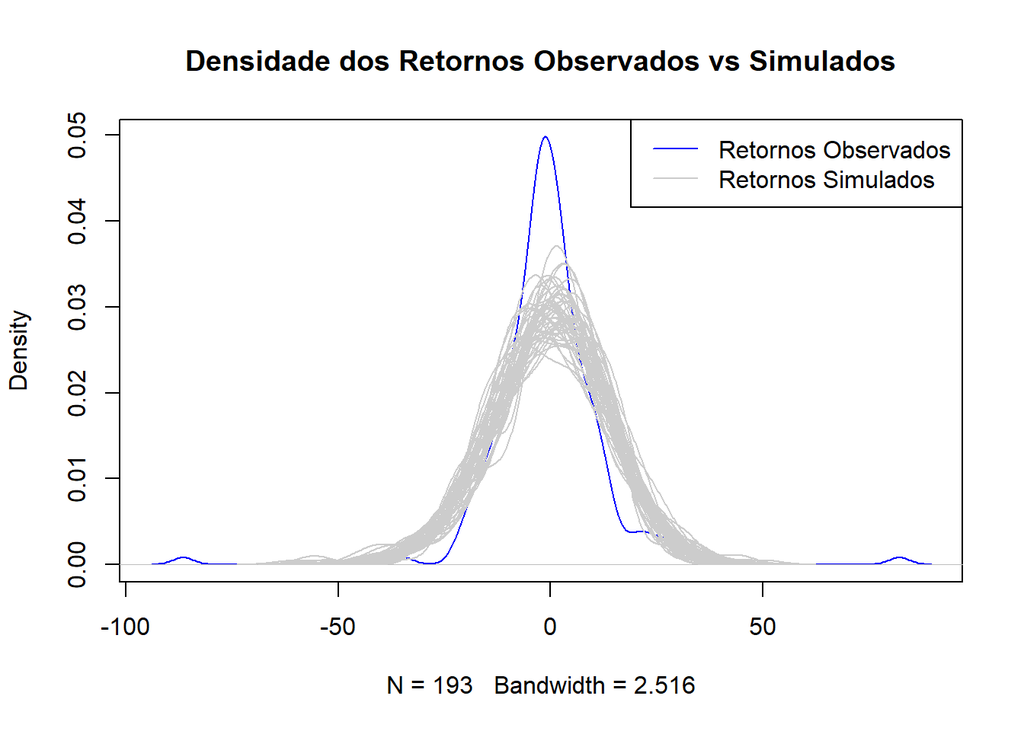

```r
# Densidade empírica dos retornos observados da Ford
plot(density(dados_capm_retexc$retexc_ford),
     col = "blue",
     main = "Densidade dos Retornos Observados vs Simulados")

# Adiciona as densidades das séries simuladas no gráfico
for (i in 1:50) {
  lines(density(sim_retexc_ford[, i]), col = "grey80")
}

# Adiciona uma legenda para identificar as densidades observadas
legend("topright",
       legend = c("Retornos Observados", "Retornos Simulados"),
       col = c("blue", "grey80"),
       lty = 1)
```

Este não parece ser um bom modelo. As densidades dos retornos simulados não se parecem com a densidade dos retornos observados. Isso sugere que o modelo CAPM estimado não é adequado para explicar os retornos excedentes da Ford. Isso pode ser devido a uma série de razões, incluindo a simplicidade do modelo, variáveis omitidas, a presença de heterocedasticidade, a presença de outliers, entre outros fatores.

Essa estratégia de simulação é uma maneira de avaliar a adequação de um modelo de regressão (linear ou não linear) estimado, que não envolve avaliar a qualidade do ajuste de um modelo de regressão, usando apenas o critério da significância estatística dos coeficientes estimados e/ou de testes de hipóteses de diagnóstico dos resíduos, sendo defendida por estatísticos e econometristas como uma abordagem complementar e útil para avaliar a adequação de um modelo estimado.

# R Notebook em HTML

Após finalizar a execução de todos os código de interesse anteriores, você pode salvar o notebook em HTML clicando no botão *Preview* na barra de ferramentas do RStudio. O arquivo HTML gerado pode ser compartilhado com outras pessoas, que poderão visualizar os resultados e gráficos sem precisar executar o código R.